# Final_EDAV_project

Plotting the number of auctions based on location, season and year turned out to have similar results and confirmed ideas suggested above.

```r
##Auctions by location, year, season

MyData3 <- subset(MyData, select=c( "auction_id", "location" ))

MyData3 <- MyData3[!duplicated(MyData3$auction_id),]

MyData4 <- MyData3 %>% group_by(location)%>% count(auction_id) %>% summarise(B=sum(n))
MyData4
```

```
## # A tibble: 8 x 2
##   location      B
##   <fct>     <int>
## 1 AMSTERDAM    10
## 2 DOHA          3
## 3 DUBAI         1
## 4 HONG KONG    10
## 5 LONDON       86
## 6 MILAN        18
## 7 NEW YORK     69
## 8 PARIS        37
```

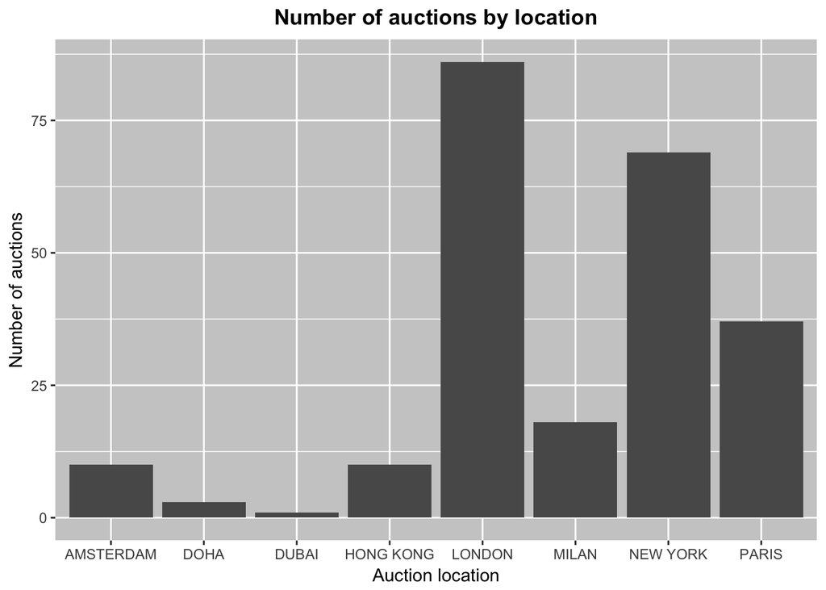

```r
ggplot(MyData4, aes(x= location, y = B)) +
    geom_bar( stat='identity')  +labs(x = "Auction location")+labs(y = "Number of auctions") + ggtitle("Number of auctions by location") + theme(plot.title = element_text(hjust = 0.5,face="bold"), panel.background = element_rect(fill = 'grey80'))
```

```r
##Auctions by season

MyData3 <- subset(MyData, select=c( "auction_id", "auc_season" ))

MyData3 <- MyData3[!duplicated(MyData3$auction_id),]

MyData4 <- MyData3 %>% group_by(auc_season)%>% count(auction_id) %>% summarise(B=sum(n))
MyData4
```

```
## # A tibble: 4 x 2
##   auc_season     B
##   <fct>      <int>
## 1 fall          36
## 2 spring        91
## 3 summer        74
## 4 winter        33
```

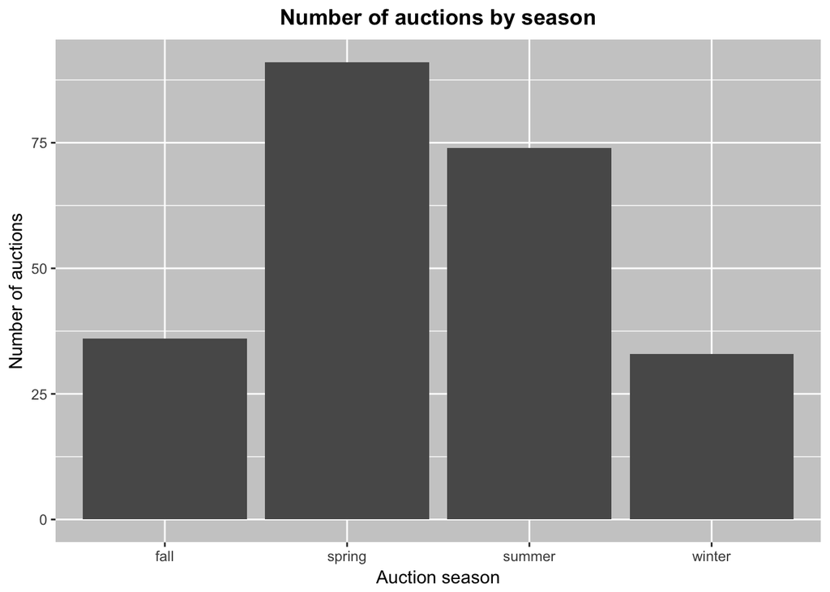

```r
ggplot(MyData4, aes(x= auc_season, y = B)) +
    geom_bar( stat='identity')  +labs(x = "Auction season")+labs(y = "Number of auctions") + ggtitle("Number of auctions by season") + theme(plot.title = element_text(hjust = 0.5,face="bold"), panel.background = element_rect(fill = 'grey80'))
```

```r
##Auctions by season

MyData3 <- subset(MyData, select=c( "auction_id", "auc_year" ))

MyData3 <- MyData3[!duplicated(MyData3$auction_id),]

MyData4 <- MyData3 %>% group_by(auc_year)%>% count(auction_id) %>% summarise(B=sum(n))
MyData4
```

```
## # A tibble: 12 x 2
##    auc_year     B
##       <int> <int>
##  1     2006     2
##  2     2007     5
##  3     2009    10
##  4     2010    27
##  5     2011    22
##  6     2012    24
##  7     2013    26
##  8     2014    24
##  9     2015    24
## 10     2016    25
## 11     2017    40
## 12     2018     5
```

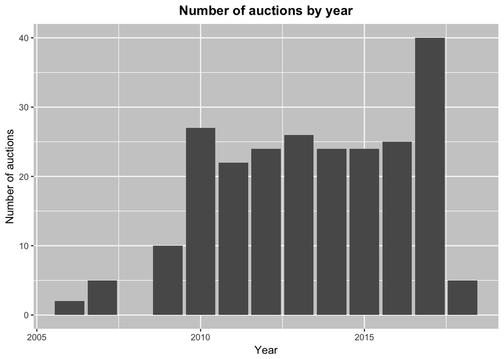

```r
ggplot(MyData4, aes(x= auc_year, y = B)) +
    geom_bar( stat='identity')+labs(y = "Number of auctions")+labs(x = "Year") + ggtitle("Number of auctions by year") + theme(plot.title = element_text(hjust = 0.5,face="bold"), panel.background = element_rect(fill = 'grey80'))
```

To see what are the different triggers of variability in art prices we decided to explore fluctuations in Hammer Prices. We created a histogram with a density curve to visualize the distribution of Hammer Price.

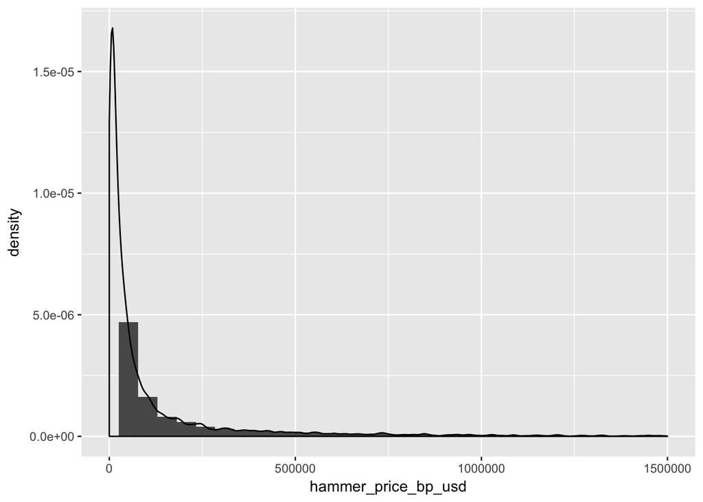

```r
##Hammer Price
ggplot(MyData, aes(x= hammer_price_bp_usd)) + geom_histogram(aes(y=..density..))  + geom_density() + xlim(0,1500000)
```

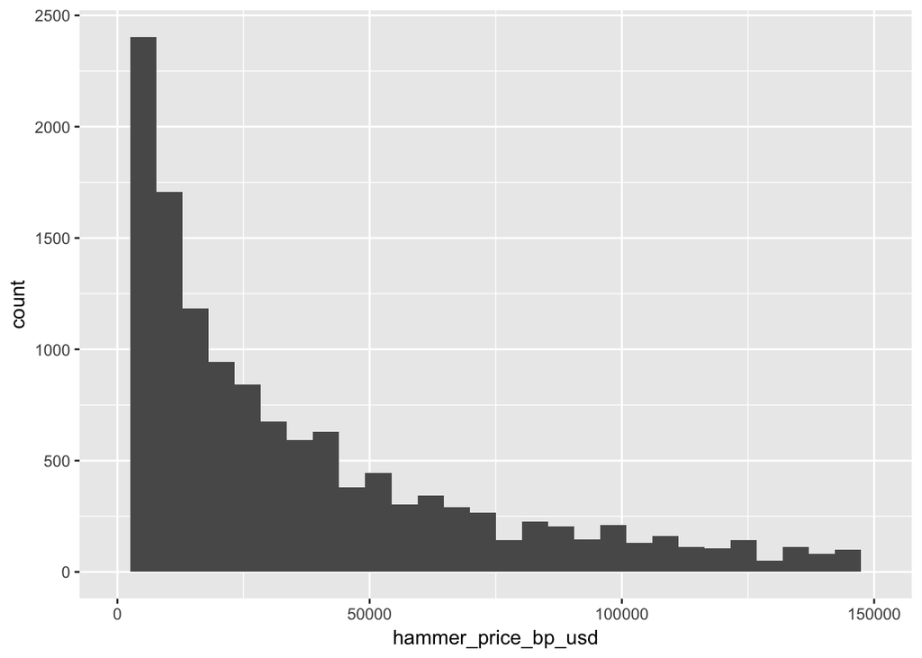

```r
ggplot(MyData, aes(x = hammer_price_bp_usd)) + geom_histogram() +xlim(0,150000)
```

Distribution of Hammer Price is skewed to the right and has a long tail. We believe the reason for this is variability in art geners (Contemporary vs Renaissance for example) sold on the market. Some older masterpieces can be traded at prices that are completly out of range for contemporary artists.